# Model evaluation for clt

The observations for the validation were taken from 2015-01-29 to 2023-12-03.

Remember that we have on a daily scale the variables `sfcWind`, `tas`, `pr`, `tasmax`, `tasmin` and `psl` and in a monthly scale `clt`, `rsdt`,`rsds` as a predictors. We also have the month and the daily daylight amount in seconds as a predictors too.

|  | mae | cor | ratio_of_sd | KGE | amplitude_mae_monthly | sign_correlation | extreme_correlation | qqplot_mae | acf_mae | extremogram_mae |
| --- | --- | --- | --- | --- | --- | --- | --- | --- | --- | --- |
| xgboost | 12.073 | 0.840 | 0.813 | 0.754 | 16.108 | 0.754 | 0.533 | 4.804 | 0.024 | 0.020 |
| cnn | 14.416 | 0.770 | 0.809 | 0.682 | 16.827 | 0.716 | 0.441 | 5.402 | 0.036 | 0.031 |
| naive | 14.545 | 0.764 | 0.760 | 0.665 | 16.973 | 0.699 | 0.516 | 7.479 | 0.050 | 0.018 |
| lstm | 12.338 | 0.824 | 0.864 | 0.782 | 13.447 | 0.750 | 0.583 | 3.781 | 0.020 | 0.022 |

## Time series of the first days

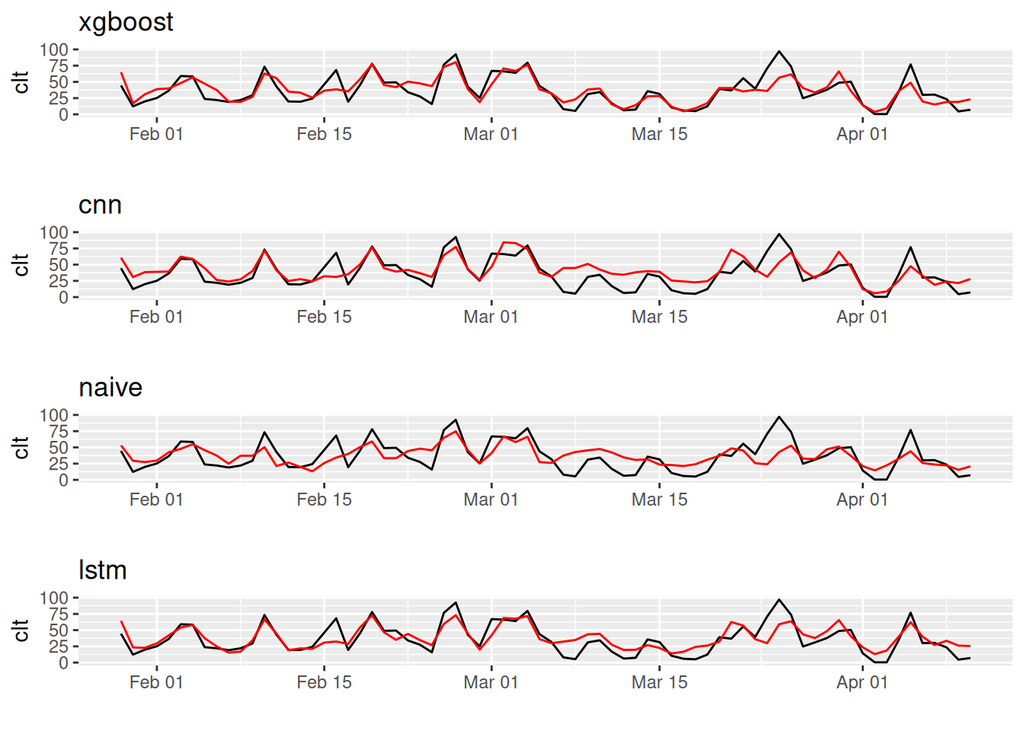

## QQ Plot

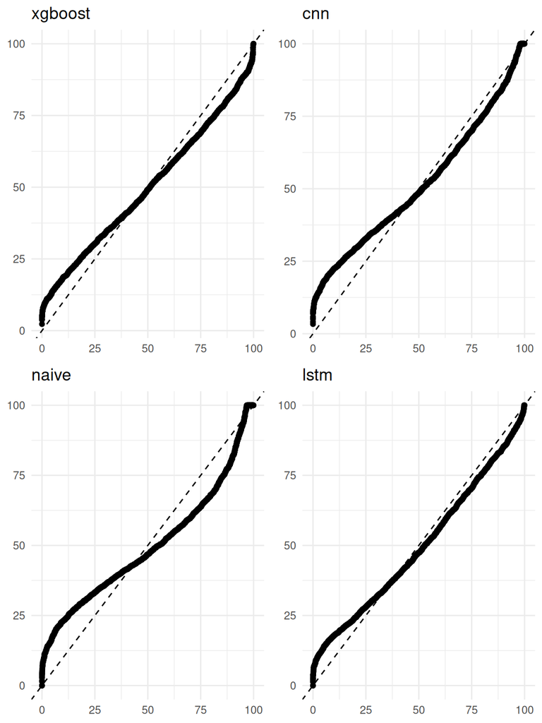

## Distribution of the undownscaled value on days with estimated extremes values.

The purpose of this plot is to illustrate the distribution of P(undownscaled value | we predicted an extreme). This is useful because it reveals how much information we can recover concerning extreme events. If the distribution is skewed to the right, it suggests that we’re predicting extreme values only when extreme values have already occurred. Conversely, if the lower tail of the distribution resembles the reanalysis data, it indicates that we can capture short-duration extremes (e.g., brief periods of heavy rainfall, such as an intense downpour lasting an hour before stopping).

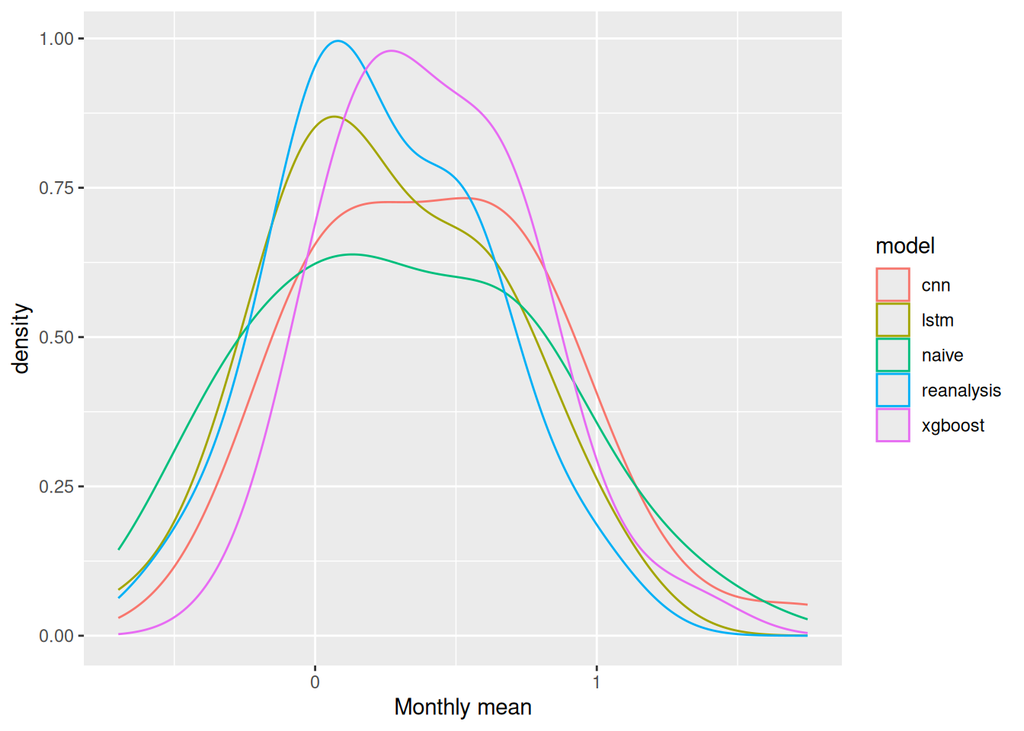

## Autocorrelogram

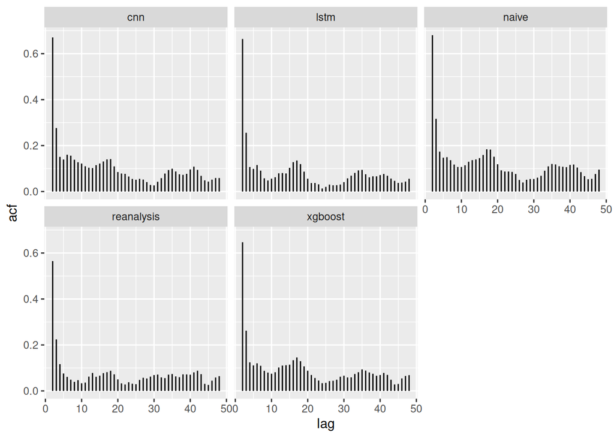

## Extremogram

*Important:* Right now we are only estimating the upper tail extremogram. Currently we didn’t find a way to estimate the two tales at the same time. We are using `quant = .97`

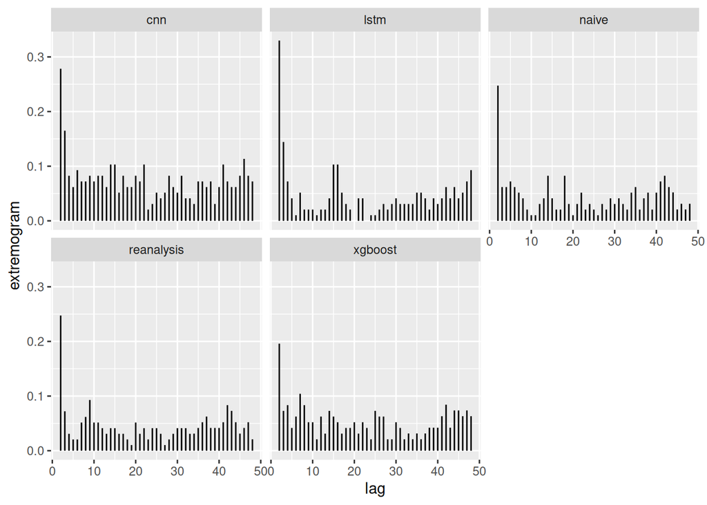

## Model Explanation

### XGBoost

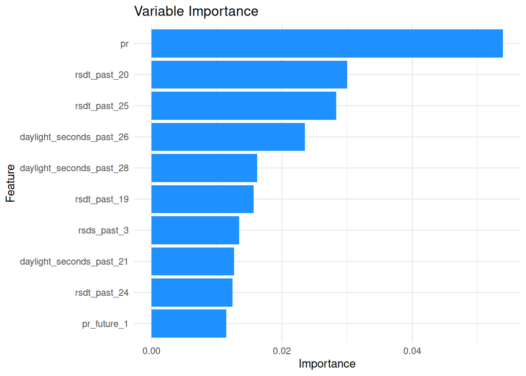